# SAN linear regression – Boston data

2023-10-02

# Learn a simple regression model

This script stems from the lab accompanying Chapter 3 of Introduction to Statistical Learning. We will use Boston data set available in MASS to predict median house value in neighborhoods around Boston. In the beginning we will work with the single independent variable: the variable $lstat$ captures the percentage of population with lower economical status in the given neighborhood (a town, an area). We will learn the model and see its basic statistics.

```r
help(Boston) # learn the structure of the dataset, 506 areas described by 14 variables, medv will serve as the target variable
```

```
## starting httpd help server ... done
```

```r
head(Boston)
```

```
##      crim zn indus chas   nox    rm  age    dis rad tax ptratio  black lstat
## 1 0.00632 18  2.31    0 0.538 6.575 65.2 4.0900   1 296    15.3 396.90  4.98
## 2 0.02731  0  7.07    0 0.469 6.421 78.9 4.9671   2 242    17.8 396.90  9.14
## 3 0.02729  0  7.07    0 0.469 7.185 61.1 4.9671   2 242    17.8 392.83  4.03
## 4 0.03237  0  2.18    0 0.458 6.998 45.8 6.0622   3 222    18.7 394.63  2.94
## 5 0.06905  0  2.18    0 0.458 7.147 54.2 6.0622   3 222    18.7 396.90  5.33
## 6 0.02985  0  2.18    0 0.458 6.430 58.7 6.0622   3 222    18.7 394.12  5.21
##   medv
## 1 24.0
## 2 21.6
## 3 34.7
## 4 33.4
## 5 36.2
## 6 28.7
```

```r
View(Boston)
## Simple linear regression
## Start with a basic regression using the lm(y ~ x, data) function
lm.fit <- lm(medv ~ lstat, data = Boston) # lstat gives the percent of households with low socioeconomic status in the neighborhood
## Understand the model
summary(lm.fit) # see the model
```

```
##
## Call:
## lm(formula = medv ~ lstat, data = Boston)
##
## Residuals:
##     Min      1Q  Median      3Q     Max
## -15.168  -3.990  -1.318   2.034  24.500
##
## Coefficients:
##             Estimate Std. Error t value Pr(>|t|)
## (Intercept) 34.55384    0.56263   61.41   <2e-16 ***
## lstat       -0.95005    0.03873  -24.53   <2e-16 ***
## ---
## Signif. codes:  0 '***' 0.001 '**' 0.01 '*' 0.05 '.' 0.1 ' ' 1
##
## Residual standard error: 6.216 on 504 degrees of freedom
## Multiple R-squared:  0.5441, Adjusted R-squared:  0.5432
## F-statistic: 601.6 on 1 and 504 DF,  p-value: < 2.2e-16
```

```r
names(lm.fit) # get all component names of the lm model
```

```
##  [1] "coefficients"  "residuals"     "effects"       "rank"
##  [5] "fitted.values" "assign"        "qr"            "df.residual"
##  [9] "xlevels"       "call"          "terms"         "model"
```

```r
coef(lm.fit) # see the coefficeints once more, same as lm.fit$coefficients
```

```
## (Intercept)       lstat
##  34.5538409  -0.9500494
```

```r
confint(lm.fit) # confidence intervals around these estimates
```

```
##                 2.5 %     97.5 %
## (Intercept) 33.448457 35.6592247
## lstat       -1.026148 -0.8739505
```

```r
sum(residuals(lm.fit)^2) # RSS
```

```
## [1] 19472.38
```

```r
sqrt(sum(residuals(lm.fit)^2)/(nrow(Boston)-2)) # RSE, it can be interpreted as the estimate of standard deviation of the noise in our model
```

```
## [1] 6.21576
```

There are further ways to understand the model.

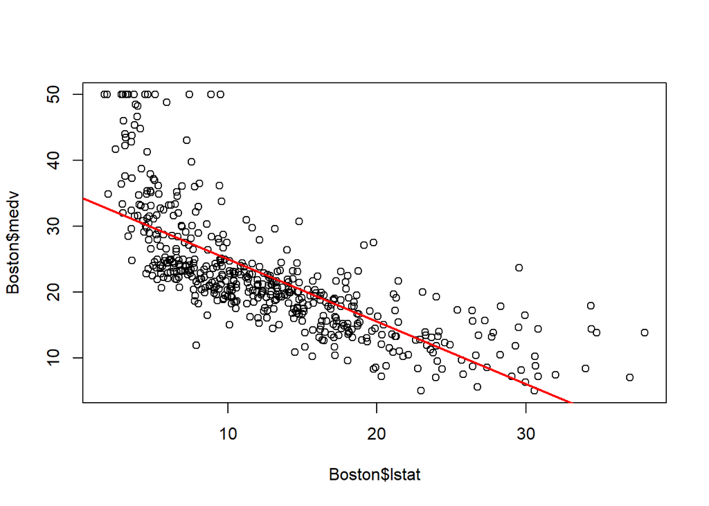

```r
plot(Boston$lstat, Boston$medv) # visualize the relationship between indep and dep variable
abline(lm.fit, col="red", lw=2) # visualize the fit
```

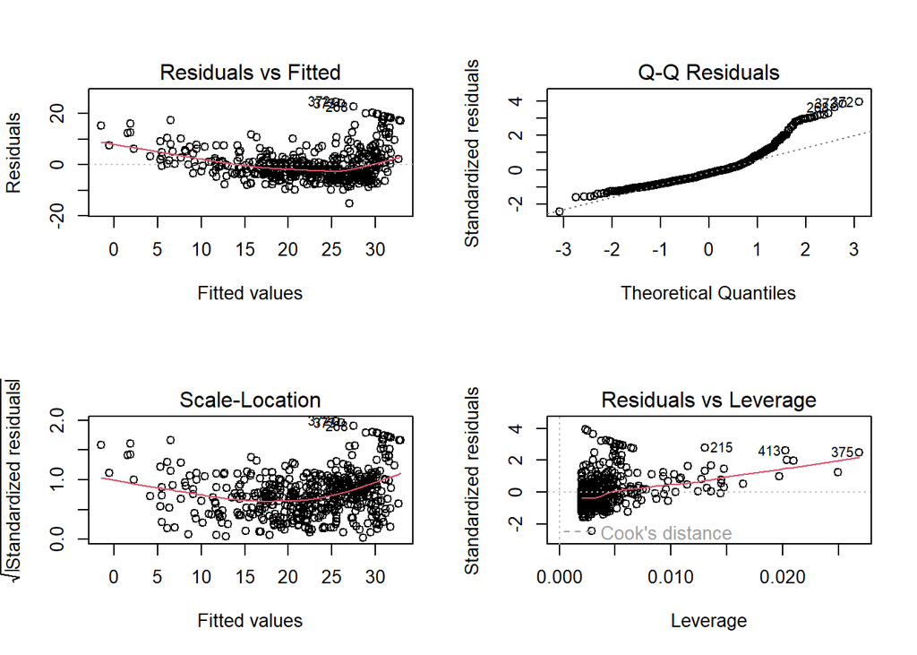

```r
par(mfrow=c(2,2))
plot(lm.fit) # see the diagnostic plots
```

```r
predict(lm.fit, data.frame(lstat=c(5,10,15)), interval = "confidence") # predict for three new neighborhoods including confints
```

```
##        fit      lwr      upr
## 1 29.80359 29.00741 30.59978
## 2 25.05335 24.47413 25.63256
## 3 20.30310 19.73159 20.87461
```

```
## 375
## 375
```

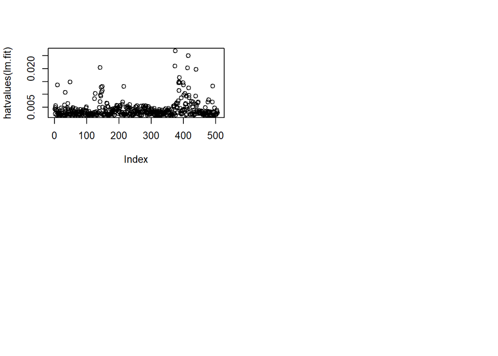

```r
plot(hatvalues(lm.fit)) # Leverage statistics can be computed for our predictors with hatvalues()
which.max(hatvalues(lm.fit)) # find the observation with the largest leverage
```

In summary, we can conclude the following. There is an obvious relationship between the independent variable (household status) and the dependent variable (median house value). Both the F-stat for the whole model and t-stat for the predictor are significant, the predictor helps to explain more than 50% of the variance in the target variable. The median house price is around $34500, on average it dercreases by $950 with one percent increase of households with low socio-economical status. For more than 30% it virtually becomes $0 (the model does not extrapolate well for these unobserved values). Both simple plot and residual plot suggest that the relationship is rather non-linear. Consequences: prediction could be improved with additional non-linear terms, assumptions are violated, estimations do not have to be perfect (namely p-values, confidence intervals).

**Further questions and tasks:**

1. Construct a multiple linear regression model. Start with a full model that deals with all the independent variables. Compare it with the simple model above. Show at least two meaningful ways to compare models of different sizes. Did you improve the simple model?

```r
lm.full <- lm(medv ~ ., data = Boston)
summary(lm.full)
```

```
##
## Call:
## lm(formula = medv ~ ., data = Boston)
##
## Residuals:
##     Min      1Q  Median      3Q     Max
## -15.595  -2.730  -0.518   1.777  26.199
##
## Coefficients:
##               Estimate Std. Error t value Pr(>|t|)
## (Intercept)  3.646e+01  5.103e+00   7.144 3.28e-12 ***
## crim        -1.080e-01  3.286e-02  -3.287 0.001087 **
## zn           4.642e-02  1.373e-02   3.382 0.000778 ***
## indus        2.056e-02  6.150e-02   0.334 0.738288
## chas         2.687e+00  8.616e-01   3.118 0.001925 **
## nox         -1.777e+01  3.820e+00  -4.651 4.25e-06 ***
## rm           3.810e+00  4.179e-01   9.116  < 2e-16 ***
## age          6.922e-04  1.321e-02   0.052 0.958229
## dis         -1.476e+00  1.995e-01  -7.398 6.01e-13 ***
## rad          3.060e-01  6.635e-02   4.613 5.07e-06 ***
## tax         -1.233e-02  3.760e-03  -3.280 0.001112 **
## ptratio     -9.527e-01  1.308e-01  -7.283 1.31e-12 ***
## black        9.312e-03  2.686e-03   3.467 0.000573 ***
## lstat       -5.248e-01  5.072e-02 -10.347  < 2e-16 ***
## ---
## Signif. codes:  0 '***' 0.001 '**' 0.01 '*' 0.05 '.' 0.1 ' ' 1
##
## Residual standard error: 4.745 on 492 degrees of freedom
## Multiple R-squared:  0.7406, Adjusted R-squared:  0.7338
## F-statistic: 108.1 on 13 and 492 DF,  p-value: < 2.2e-16
```

```r
coef(lm.full) # see the coefficeints once more, same as lm.fit$coefficients
```

```
##   (Intercept)          crim            zn         indus          chas
##  3.645949e+01 -1.080114e-01  4.642046e-02  2.055863e-02  2.686734e+00
##           nox            rm           age           dis           rad
## -1.776661e+01  3.809865e+00  6.922246e-04 -1.475567e+00  3.060495e-01
##           tax       ptratio         black         lstat
## -1.233459e-02 -9.527472e-01  9.311683e-03 -5.247584e-01
```

```r
confint(lm.full) # confidence intervals around these estimates
```

```
##                     2.5 %        97.5 %
## (Intercept)  26.432226009  46.486750761
## crim         -0.172584412  -0.043438304
## zn            0.019448778   0.073392139
## indus        -0.100267941   0.141385193
## chas          0.993904193   4.379563446
## nox         -25.271633564 -10.261588893
## rm            2.988726773   4.631003640
## age          -0.025262320   0.026646769
## dis          -1.867454981  -1.083678710
## rad           0.175692169   0.436406789
## tax          -0.019723286  -0.004945902
## ptratio      -1.209795296  -0.695699168
## black         0.004034306   0.014589060
## lstat        -0.624403622  -0.425113133
```

```r
sum(residuals(lm.full)^2) # RSS
```

```
## [1] 11078.78
```

### My answer

From the comparison of the simple and full linear regression models, the full model improved the fit compared to the simple one:

- **Residual Standard Error** decreased from 6.2 to 4.7, meaning the predictions are closer to the observed house prices.
- **Multiple** $R^2$ increased from 0.544 to 0.741.
- **Adjusted** $R^2$ rose from 0.543 to 0.734, showing that even after penalizing for additional variables, the model explains about 20% more variance.
- **The Residual Sum of Squares** decrease significantly from 19472.38 to 11078.78.

Then F-test was highly significant ($F = 108.1$, $p < 2.2 \times 10^{-16}$), confirming a strong relationship between variables and the outcome. Individual t-tests revealed that some variables (such as indus and age) are not significant, suggesting potential for simplifying the model.

Overall, the full model substantially improved performance by reducing error and increasing explanatory power, while highlighting which variables contribute most meaningfully.

2. Propose a linear regression model of the right size. Focus on simple approaches, more advanced methods (shrinkage, etc.) will be practiced during the next lab.

```r
lm.reduced_1 <- lm(medv ~ . - indus - age, data = Boston)
summary(lm.reduced_1)
```

```
##
## Call:
## lm(formula = medv ~ . - indus - age, data = Boston)
##
## Residuals:
##      Min       1Q   Median       3Q      Max
## -15.5984  -2.7386  -0.5046   1.7273  26.2373
##
## Coefficients:
##               Estimate Std. Error t value Pr(>|t|)
## (Intercept)  36.341145   5.067492   7.171 2.73e-12 ***
## crim         -0.108413   0.032779  -3.307 0.001010 **
## zn            0.045845   0.013523   3.390 0.000754 ***
## chas          2.718716   0.854240   3.183 0.001551 **
## nox         -17.376023   3.535243  -4.915 1.21e-06 ***
## rm            3.801579   0.406316   9.356  < 2e-16 ***
## dis          -1.492711   0.185731  -8.037 6.84e-15 ***
## rad           0.299608   0.063402   4.726 3.00e-06 ***
## tax          -0.011778   0.003372  -3.493 0.000521 ***
## ptratio      -0.946525   0.129066  -7.334 9.24e-13 ***
## black         0.009291   0.002674   3.475 0.000557 ***
## lstat        -0.522553   0.047424 -11.019  < 2e-16 ***
## ---
## Signif. codes:  0 '***' 0.001 '**' 0.01 '*' 0.05 '.' 0.1 ' ' 1
##
## Residual standard error: 4.736 on 494 degrees of freedom
## Multiple R-squared:  0.7406, Adjusted R-squared:  0.7348
## F-statistic: 128.2 on 11 and 494 DF,  p-value: < 2.2e-16
```

```r
coef(lm.reduced_1) # see the coefficeints once more, same as lm.fit$coefficients
```

```
##   (Intercept)          crim            zn          chas           nox
##  36.341145004  -0.108413345   0.045844929   2.718716303 -17.376023429
##            rm           dis           rad           tax       ptratio
##   3.801578840  -1.492711460   0.299608454  -0.011777973  -0.946524570
##         black         lstat
##   0.009290845  -0.522553457
```

```r
confint(lm.reduced_1) # confidence intervals around these estimates
```

```
##                     2.5 %       97.5 %
## (Intercept)  26.384649126  46.29764088
## crim         -0.172817670  -0.04400902
## zn            0.019275889   0.07241397
## chas          1.040324913   4.39710769
## nox         -24.321990312 -10.43005655
## rm            3.003258393   4.59989929
## dis          -1.857631161  -1.12779176
## rad           0.175037411   0.42417950
## tax          -0.018403857  -0.00515209
## ptratio      -1.200109823  -0.69293932
## black         0.004037216   0.01454447
## lstat        -0.615731781  -0.42937513
```

```r
sum(residuals(lm.reduced_1)^2) # RSS
```

```
## [1] 11081.36
```

### My answer

From the output of linear regression with all variables, the variables **indus** and **age** had the largest p-values, meaning they were not statistically significant. Because of that I excluded them and refitted the model. The results show that the model performance only slightly changed compared to the full model:

- **Residual Standard Error** stayed at about 4.7.
- **Multiple** $R^2$ remained around 0.74.
- **Adjusted** $R^2$ also stayed around 0.73.
- **The Residual Sum of Squares** increased slightly from 11078.78 to 11081.36, which is not a significant change.

Overall, the model was simplified without significant loss in performance.

```r
lm.reduced_2 <- lm(medv ~ . - crim - chas - indus - age, data = Boston)
summary(lm.reduced_2)
```

```
##
## Call:
## lm(formula = medv ~ . - crim - chas - indus - age, data = Boston)
##
## Residuals:
##      Min       1Q   Median       3Q      Max
## -12.8917  -2.7329  -0.4988   1.8547  26.6433
##
## Coefficients:
##               Estimate Std. Error t value Pr(>|t|)
## (Intercept)  35.459724   5.158054   6.875 1.87e-11 ***
## zn            0.041396   0.013737   3.013 0.002715 **
## nox         -15.502932   3.583879  -4.326 1.84e-05 ***
## rm            3.879580   0.414180   9.367  < 2e-16 ***
## dis          -1.451648   0.187926  -7.725 6.26e-14 ***
## rad           0.252412   0.061778   4.086 5.12e-05 ***
## tax          -0.012360   0.003427  -3.606 0.000342 ***
## ptratio      -0.968703   0.131248  -7.381 6.69e-13 ***
## black         0.010842   0.002705   4.008 7.06e-05 ***
## lstat        -0.555124   0.047699 -11.638  < 2e-16 ***
## ---
## Signif. codes:  0 '***' 0.001 '**' 0.01 '*' 0.05 '.' 0.1 ' ' 1
##
## Residual standard error: 4.832 on 496 degrees of freedom
## Multiple R-squared:  0.7289, Adjusted R-squared:  0.724
## F-statistic: 148.2 on 9 and 496 DF,  p-value: < 2.2e-16
```

```r
coef(lm.reduced_2) # see the coefficeints once more, same as lm.fit$coefficients
```

```
##  (Intercept)           zn          nox           rm          dis          rad
##  35.45972402   0.04139641 -15.50293183   3.87957998  -1.45164758   0.25241226
##          tax      ptratio        black        lstat
##  -0.01236042  -0.96870272   0.01084164  -0.55512420
```

```r
confint(lm.reduced_2) # confidence intervals around these estimates
```

```
##                     2.5 %       97.5 %
## (Intercept)  25.325395676 45.594052365
## zn            0.014405754  0.068387069
## nox         -22.544387993 -8.461475676
## rm            3.065817263  4.693342695
## dis          -1.820876099 -1.082419062
## rad           0.131033046  0.373791466
## tax          -0.019094245 -0.005626592
## ptratio      -1.226572470 -0.710832976
## black         0.005527265  0.016156023
## lstat        -0.648842038 -0.461406353
```

```r
sum(residuals(lm.reduced_2)^2) # RSS
```

```
## [1] 11580.95
```

Then I tried to simplify model slightly more and I excluded **crim** and **chas** from reduced model, which had relatively high p-values compared to other variables. Output shows that the model performance became worse (higher **Residual Standard Error** and **the Residual Sum of Squares**, lower **Adjusted** $R^2$). Since all the remaining variables have smaller p-values than **crim** and **chas**, it follows that they contribute even more strongly to the model. Therefore, removing any of them would likely reduce the explanatory power even further.